# Simple Supervized Classification

Some concepts

Christophe Bontemps & Patrick Jonsson - SIAP[^1]

Supervised classification aims at explaining a binary variable $y$ (sucess/failure) by covariates $x$, say the probability of rural (of repayment of a loan) by some explanatory variables (income, …). A classifier tells us if we predict success or failure given the covariates.

We will look at some simple models of classification, as well the many dimensions that we can use to evaluate a classifier.

In statistics, we often denote $y$ as 1 or -1 (positive or negative) (we could change this to 1 and 0 but the former will be handy). So a classifier is
$$\widehat{f} (x) = 1 \ \mbox{ or } -1
\, .$$

In the data set we use here as an example, we have two predictors, *Education* and *Income*, and the dependent variable is whether the household is living in a *rural* or *urban* environment.

```r
data(twoClassData)
names(predictors) <- c("Education", "Income")
levels(classes)[levels(classes)=="Class1"] <- "Urban"
levels(classes)[levels(classes)=="Class2"] <-  "Rural"
twoClass <- data.frame(predictors,classes)
#twoClass$classes <- relevel(twoClass$classes, ref="Urban")

twoClassColor <- brewer.pal(3,'Set2')[2:1]
names(twoClassColor) <- c('Urban','Rural')
```

```r
summary(twoClass$classes)
```

```
## Urban Rural
##   111    97
```

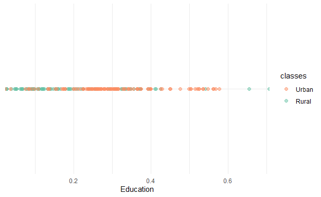

```r
# univariate plot
ggplot(data = twoClass,aes(x = Education, y= 1)) +
  geom_point(aes(color = classes), size = 2, alpha = .5) +
  scale_colour_manual(name = 'classes',
                      values = twoClassColor) +
  scale_x_continuous(expand = c(0,0)) +
  scale_y_continuous(expand = c(0,0))+
  theme_minimal()+
  theme(axis.title.y=element_blank(),
        axis.text.y=element_blank(),
        axis.ticks.y=element_blank())
```

Note that we have defined *Urban* as being the first class, but we may want to change this along the way.

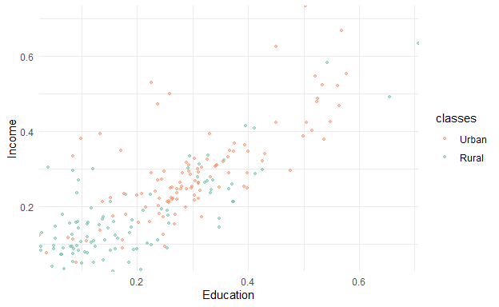

```r
ggplot(data = twoClass,aes(x = Education, y = Income)) +
  geom_point(aes(color = classes), size = 1, alpha = .5) +
  scale_colour_manual(name = 'classes',
                      values = twoClassColor) +
  scale_x_continuous(expand = c(0,0)) +
  scale_y_continuous(expand = c(0,0))+
  theme_minimal()
```

# Classifiers

```r
sixStats <- function(...) c(twoClassSummary(...),
                            defaultSummary(...))
```

```r
# control variables (see later)
K <- 5
repeats <- 10
rcvTunes <- 1 # tune number of models
seed <- 123
# repeated cross validation
rcvSeeds <- setSeeds(method = "repeatedcv",
                     numbers = K, repeats = repeats,
                     tunes = rcvTunes, seed = seed)

ctrl <- trainControl(method = "repeatedcv",
                     number = K,
                     repeats = repeats,
                     seeds = rcvSeeds,
                     classProbs = TRUE,
                     summaryFunction = sixStats)

TrControl <- trainControl(method = "none",
                          classProbs=TRUE,
                          savePredictions = TRUE)
```

## Logit as You Don’t Know It

Let’s begin with the simple logit model. This means we model
$$\Pr \left( y = 1\right) = F( x'\beta) =
\frac{1}{1+\exp(-x'\beta)}
\, ,$$
where $F(\cdot)$ is the cdf of the logistic distribution.[^2]

Estimation relies on maximum likelihood. Predicted probabilities have the form
$$\widehat{p}_{i} =
\frac{e^{x_{i}'\widehat{\beta}}}{1+e^{x_{i}'\widehat{\beta}}}
\, .$$
It is not difficult to show that
$$\log \frac{\widehat{p}_{i}}{1-\widehat{p}_{i}} =
x_{i}'\widehat{\beta}
\, .$$
The quantity $\frac{\widehat{p}_{i}}{1-\widehat{p}_{i}}$ is called the *odds*, it varies between 0 and $\infty$ and indicate very low or very high probability of rural. Logit models *log odds* as linear in $x$.

For classification, we want to predict values of $y$. So we decide that
$$\widehat{y}_{i} = 1 \Leftrightarrow \widehat{p}_{i} > t
\qquad \widehat{y}_{i} = -1 \Leftrightarrow \widehat{p}_{i} \leq t
\, .$$
The most common choice for the “cutoff” or threshold probability is $t=50\%$. Now because log-odds are increasing in $p$, if $t=1/2$, it means that
$$\widehat{y}_{i} = 1 \Leftrightarrow x_{i}'\widehat{\beta} > 0
\qquad \widehat{y}_{i} = -1
\Leftrightarrow x_{i}'\widehat{\beta} \leq 0
\, .$$

```r
Logit <- train(classes ~ . , data = twoClass,
               method = "glm",
               preProcess = c("center"),
               trControl = TrControl)
summary(Logit)
```

```
##
## Call:
## NULL
##
## Coefficients:
##             Estimate Std. Error z value Pr(>|z|)
## (Intercept)  -0.2382     0.1597  -1.491   0.1359
## Education    -2.3479     1.8524  -1.267   0.2050
## Income       -7.0376     2.1569  -3.263   0.0011 **
## ---
## Signif. codes:  0 '***' 0.001 '**' 0.01 '*' 0.05 '.' 0.1 ' ' 1
##
## (Dispersion parameter for binomial family taken to be 1)
##
##     Null deviance: 287.41  on 207  degrees of freedom
## Residual deviance: 240.01  on 205  degrees of freedom
## AIC: 246.01
##
## Number of Fisher Scoring iterations: 4
```

The classifier then depends simply on the linear combination of the $x$’s.

For any threshold $t$, not necessarily equal to $1/2$, the classifier still depends on a linear combination of $x$ (where the intercept is changed).

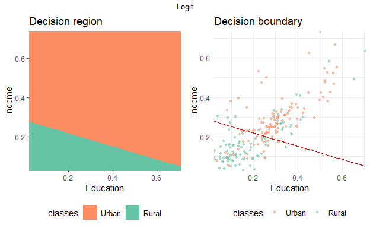

## Quadratic Logit Classifier

We could include, e.g. , quadratic terms or interactions in the model. in that case *log odds* will include those terms, and the classifier depends nonlinearly of $x$.

```r
set.seed(1410)
Logit2 <- train(classes ~ Education + Income
                + I(Education^2) + I(Income^2)
                + I(Education*Income), data=twoClass,
                method="glm",
                preProc=c("center"),
                trControl = ctrl)
```

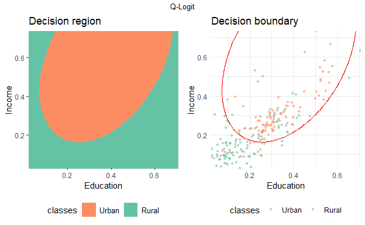

## (Bayesian) Discriminant Analysis

Bayes’ Rule says
$$p_{k} (x_{0}) = \Pr \left( y = k | x= x_{0}\right) = \frac{\Pr \left(
x=x_{0} | y = 1 \right)
\Pr \left( y = k\right)}{\Pr \left( x=x_{0}\right)}
\qquad k=1, -1
\, .$$
The goal is to estimate each of the right-hand side quantities to obtain $\widehat{p}_{1} (x_{0})$. The classifier is
$$\widehat{y}_{i} = 1 \Leftrightarrow
\widehat{p}_{1} (x_{0}) > \widehat{p}_{-1} (x_{0})
\qquad \widehat{y}_{i} = -1 \Leftrightarrow
\widehat{p}_{1} (x_{0}) \leq \widehat{p}_{-1} (x_{0})
\, .$$
How to estimate conditional probabilities? First note that
$$\log p_{k} (x_{0}) = \log \Pr \left( x=x_{0} | y = k \right) + \log \Pr
\left( y = k\right) - \log \Pr \left( x=x_{0}\right)
\, .$$
The classifier is
$$\widehat{y}_{i} = 1 \Leftrightarrow \log \widehat{p}_{1} (x_{0}) >
\log \widehat{p}_{-1} (x_{0})
\qquad \widehat{y}_{i} = -1 \Leftrightarrow
\log \widehat{p}_{1} (x_{0}) \leq \log \widehat{p}_{-1} (x_{0})
\, .$$
So we don’t need to bother about estimating $\log\Pr\left(x=x_{0}\right)$ because it cancels out.

Also we can simply estimate $\Pr\left( y = k\right)$ by $\widehat{p}_{k}$, the proportion of $y=k$ in the sample. We only have to decide how to estimate $\log\Pr\left( x=x_{0} | y = k \right)$.

Typically, discriminant Analysis makes the assumption that $x | y=k \sim N\left( \mu_{k}, \Sigma_{k} \right)$. Then we estimate $\mu_{k}$ and $\Sigma_{k}$ by ML (group means and group variances) and use
$$\log \Pr \left( x=x_{0} | y = k \right) = - \frac{p}{2} \log
|\Sigma_{k}| - \frac{p}{2} \log \left(2 \pi\right) - \frac{1}{2}
(x-\mu_{k})'\Sigma_{k}^{-1} (x-\mu_{k})
\, .$$

## Linear Discriminant Analysis

Assume $\Sigma_{k} = \Sigma$ for all $k$. Then one can estimate it by averaging the group variances. In that case comparing the log probabilities amount to compare linear functions of the $x$ (check from the above formula that quadratic parts are equal and thus do not play any role).

We estimate $\Sigma$ by ML: averaging group variance with weights (approximately) corresponding to their in-sample frequency.

```r
set.seed(1410)
Lda <- train(classes ~ ., data = twoClass,
             method = "lda" , trControl = ctrl)
```

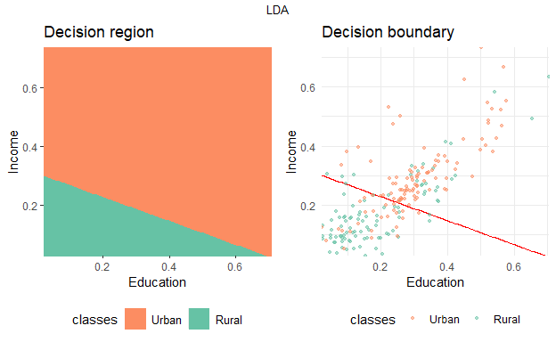

LDA is similar to linear Logit, difference comes from the way we estimate the parameters.

## Quadratic Discriminant Analysis

Does not assume $\Sigma_{k} = \Sigma$ for all $k$, and thus yields a quadratic boundary.

```r
set.seed(1410)
Qda <- train(classes ~ ., data = twoClass,
             method = "qda" , trControl = ctrl)
```

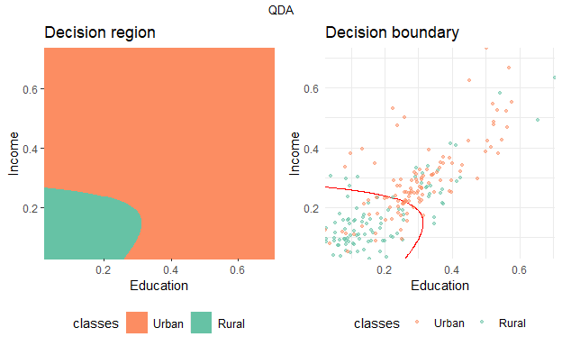

## Naive Bayes Discrimination

Assume that the components of $x$ are independent in each class. Then $\Pr \left( x=x_{0} | y = k \right) = \prod_{j=1}^p \Pr \left( x_j=x_{j,0} | y = k \right)$.

- Very useful when $x$ is high-dimensional.
- Discrete $x$ modeled as binomial or multinomial: parameters are easily estimated.
- Continuous $x$ can be modeled as Gaussian: in that case same as before but with *diagonal* variance covariance.

```r
set.seed(1410)
Bayes <- train(classes ~ ., data = twoClass,
               method = "nb" , trControl = ctrl,
               tuneGrid = data.frame(usekernel = c(FALSE),
                          fL = c(0), adjust = c(1)))
```

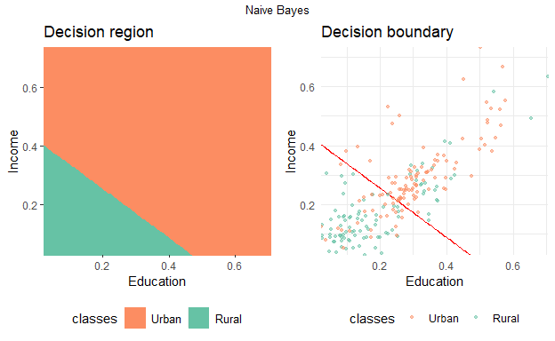

## Naive Bayes Discrimination with Kernel Density Estimation

We can estimate the (conditional) density of each $x$ with a kernel estimator.

```r
set.seed(1410)
KernelBayes <- train(classes ~ ., data = twoClass,
                     method = "nb" ,
                     trControl = ctrl,
                     tuneGrid = data.frame(
                       usekernel = c(TRUE), fL = c(0),
                       adjust = c(1)))
```

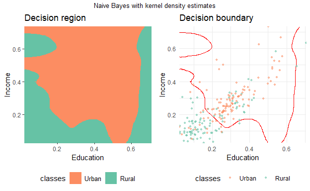

> All these models are different and provide a very differnet classification. How can we choose the right model?

# Measures of Fit in Classification

There are many ways to define the risk in classification.

## Accuracy

In supervised classification with a binary dependent $y$, an often used criterion is *accuracy*
$$\Pr \left[ y_0 = \widehat{f}(x_0) \right] =
E \left[ 1 \left( y_0 = \widehat{f}(x_0) \right) \right]$$
where $\widehat{f}(\cdot)$ is the classifier. We want the *maximum* possible accuracy. Sometimes transformed as *minimum* of *error rate* or *misclassification rate*
$$\Pr \left[ y_0 \neq \widehat{f}(x_0) \right] =
E \ 1(y_0 \neq \widehat{f}(x_0))
\, .$$

## Confusion Matrix

The **confusion matrix** provides a full count of the **observed** (or reference) *vs* **predicted** cases in each category. By convention, the categories are named “*Positive*” and “*Negative*” while successes are called “*True*” and failures “*False*”.

|  |  | Observed |  |
| --- | --- | --- | --- |
|  |  | *Positive* class | *Negative* class |
| **Predicted** | *Positive* class | **TP** (True Positive) | **FP** (False Positive) |
|  | *Negative* class | **FN** (False Positive) | **TN** (True Negative) |

> The *positive* class is our example is *Urban*

```r
Pred <- predict(Logit, newdata = twoClass)
confusion <- caret::confusionMatrix(data = Pred,
                       reference = classes,
                       positive = "Urban",
                       mode = "sens_spec")

confusion$table
```

```
##           Reference
## Prediction Urban Rural
##      Urban    87    28
##      Rural    24    69
```

### A trick to memorize this

- If it starts with **True** then the prediction was correct
- Oppositely, if it starts with **False** then the prediction was incorrect
- **Positive** or **negative** indicates the category.

From this table, we can compute the accuracy of the prediction:

```r
#confusion$overall[1]

accuracy <- (confusion$table[1] + confusion$table[4])/ nrow(twoClass)
accuracy
```

```
## [1] 0.75
```

Here the accuracy is **0.75**. But there are other, more relevant elements we can compute from this confusion table such as the specificity and sensitivity.

```r
t(cbind(t(confusion$byClass[1:2]), t(confusion$overall[1:2]))) %>%
  kable(, digit=2)
```

| Sensitivity | 0.78 |
| --- | --- |
| Specificity | 0.71 |
| Accuracy | 0.75 |
| Kappa | 0.50 |

## Evaluation metrics: Specificity, Sensitivity & Kappa indicators

When evaluating prediction there are several metrics that should be taken into account. All of them are retrieved from the confusion matrix

```r
# !["Elements of a confusion matrix"](https://www.researchgate.net/publication/273363742/figure/fig4/AS:667598647730193@1536179329823/A-simple-confusion-matrix-a-two-by-two-table-values-in-the-main-diagonal-TP-and-TN.png)]
```

The simplest one being accuracy which corresponds to the fraction of prediction that we classified correctly using our model. In the case of binary classification this will be:

$$Acuracy = \frac{True Positives + True
Negatives}{ True Positives + True Negatives + False Positives + False
Negatives} \\
\;\\
= \frac{True Positives + True Negatives}{N}$$

### Limitations of Accuracy

As mentioned before accuracy does not work as well when there is heavy imbalance between classes. If 90% of the data corresponds to one class, then you can reach 90% accuracy by simply guessing that class for all observations in the data. **Accuracy** also does not give information about what type of mistake you are making, which can be important if one mistake is more costly to make than the other.

- No difference between the different types of error: costs of different mistakes can be very different.
- One must consider the natural frequencies of each class: if rural was very rare event, we could always reach almost perfect accuracy by always predicting no rural. So we want to compare accuracy to the *prevalence rate*.

Here the overall probability or *prevalence rate* is $\widehat{p}= 97/(111+97) = 0.47$. So using a threshold of $1/2$, we predict in the sample that no one is rural, so the *no-information accuracy rate* is indeed 0.53.

A common problem in classification is that if a class has a low probability (*severe imbalance*), then a classifier that never predicts this class has a low probability of misclassification: if there is only 1 percent of positive, then a classifier that never predict positive is wrong **only** 1 percent of the time!

Another issue with class imbalance is that splitting a sample may yield a subsample with no observations in some class. Use **createDataPartition** to create balanced splits of the data. If the $y$ argument to this function is a factor, the random sampling occurs within each class and should preserve the overall class distribution of the data. For K-fold CV, use **createFolds** or **createMultiFolds**. See a later chapter for more.

To avoid the downsides of accuracy there are alternative metrics such as , **Sensitivity**, **Specificity** and **Kappa** which can be used instead:

$$Specificity = \frac{True
Negatives}{True Negatives + False Positives}$$
Whereas **specificity** corresponds to the fraction of observations who where correctly classified as Rural (non Urban), out of all the observations that are Rural (not Urban).

Finally **Kappa** is similar to the classic accuracy measure, but it is able to take into consideration the data sets class imbalance.

$$\kappa =
\frac{p_o-p_e}{1-p_e}$$

For binary classification **Kappa** can be rewritten as an expression of True Positives (TP), False Negatives (FN), False Negatives (FN), and False Positives (FP):

$$\kappa = \frac{2(TP \cdot TN - FN \cdot
FP)}{(TP + FP) \cdot (FP + TN)+ (TP+FN) \cdot (FN + TN)}$$

where $p_o$ is the accuracy of the model, and $p_e$ is the measure of the agreement between the model predictions and the actual class values as if happening by chance. The *Kappa* value indicates how much better the model is performing compared to a different model that makes random classifications based on the distribution of the target variable.

- $\kappa$ can take values between -1 and 1, but in practice is between 0 and 1, since we expect $P_o > p_E$. The larger $\kappa$ is, the better the model compared to expected accuracy using non-information predicted probability.
- Depending on whether classes are evenly distributed, $\kappa$ can be moderate or high.
- If expected accuracy is $1/2$ as here, then $\kappa = 2 \times p_o -1$, sp there is no difference in ranking using $\kappa$ or observed accuracy.
- If accuracy is high, say 90%, but expected accuracy is also high, say 85%, $\kappa$ show moderate agreement, here $1/3$.

> All these measures are directly computed for a classifier

```r
caret::confusionMatrix(data = Pred,
                       reference = classes,
                       positive = "Rural",
                       mode = "sens_spec")
```

```
## Confusion Matrix and Statistics
##
##           Reference
## Prediction Urban Rural
##      Urban    87    28
##      Rural    24    69
##
##                Accuracy : 0.75
##                  95% CI : (0.6854, 0.8073)
##     No Information Rate : 0.5337
##     P-Value [Acc > NIR] : 1.073e-10
##
##                   Kappa : 0.4964
##
##  Mcnemar's Test P-Value : 0.6774
##
##             Sensitivity : 0.7113
##             Specificity : 0.7838
##          Pos Pred Value : 0.7419
##          Neg Pred Value : 0.7565
##              Prevalence : 0.4663
##          Detection Rate : 0.3317
##    Detection Prevalence : 0.4471
##       Balanced Accuracy : 0.7476
##
##        'Positive' Class : Rural
##
```

- Precision = True Positive / Total Predicted Positive = TP/(TP + FP).
- False Discovery Rate = 1 - Precision.

> For a more in depth discussion of these concepts, see the post by Nina Zummel[^3].

# In practice: Example with the logit

As for any model, the logit classifier is based on the estimation of the probability model. Note that it is always a good practice to center and/or standardize the variables prior to estimation.

```r
Logit <- train(classes ~ . , data = twoClass,
               method = "glm",
               preProcess = c("center"),
               trControl = TrControl)
summary(Logit)
```

```
##
## Call:
## NULL
##
## Coefficients:
##             Estimate Std. Error z value Pr(>|z|)
## (Intercept)  -0.2382     0.1597  -1.491   0.1359
## Education    -2.3479     1.8524  -1.267   0.2050
## Income       -7.0376     2.1569  -3.263   0.0011 **
## ---
## Signif. codes:  0 '***' 0.001 '**' 0.01 '*' 0.05 '.' 0.1 ' ' 1
##
## (Dispersion parameter for binomial family taken to be 1)
##
##     Null deviance: 287.41  on 207  degrees of freedom
## Residual deviance: 240.01  on 205  degrees of freedom
## AIC: 246.01
##
## Number of Fisher Scoring iterations: 4
```

The classifier depends simply on the linear combination of the $x$’s. For any threshold $t_0$, not necessarily equal to $1/2$, the classifier still depends on a linear combination of $x$ (where the intercept is changed).

## The impact of the threshold

> The logit models log of odd ratios as linear in $x$

$$\log \frac{\widehat{p}_{i}}{1-\widehat{p}_{i}} =
x_{i}'\widehat{\beta}
\, .$$

where $\frac{\widehat{p}_{i}}{1-\widehat{p}_{i}}$ are the *odds*, which varies between 0 and $\infty$ and indicate very low or very high probability of Urban.

For classification, we have seen that we use the prediction values of $y$. So we decide that
$$\widehat{p}_{i} > 1/2 \Leftrightarrow \widehat{y}_{i} = 1$$
Here we have decided that the “cutoff” or threshold probability is $t=50% $. Now because log-odds are increasing in $p$, if $t_0=1/2$, it means that:

$$x_{i}'\widehat{\beta} > 0 \Leftrightarrow \widehat{y}_{i} = 1
x_{i}'\widehat{\beta} > 0$$
But the threshold may not be 0.50, in particular if observe that $y = 1$ in only 20 or 30% of the case, why choose a threshold at 50%?

The more general rule is:
$$\widehat \pi_i > t_0 \Leftrightarrow \widehat y_i = 1$$

Where $t_0$ is a threshold provability, by default $1/2$. If $t_0 \neq 1/2$, we ahve
$$x'_i \widehat \beta > T_0 \Leftrightarrow \widehat y_i = 1$$
The logit classifier depends on the linear combination of the x’s The rule $x'\beta \geq T_0$ defines the partition of the space and this partition is sensitive to the choice of the threshold $T_0$ (and the $t_0$). For any threshold $t$, not necessarily equal to $1/2$, the classifier still depends on a linear combination of $x$ (where the intercept is changed). So: + Changing $t_0$ will change the predictions & the classification + A higher $t_0$ will allocate less observations to the $y=1$ category (Urban) + A lower $t_0$ will allocate more observations to the $y=1$ category + The choice of $t_0$ should be done according to the data and observed classes repartition + Specificity and Sensitivity are affected by $t_0$

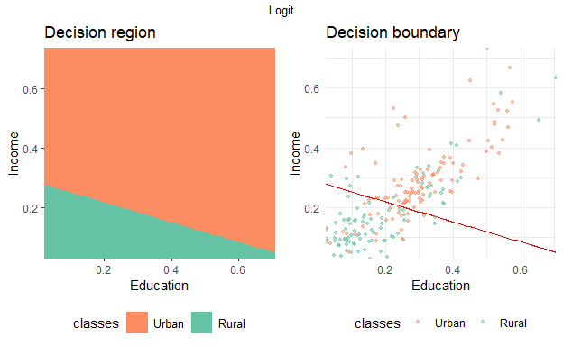

## Receiving Operating Characteristic (ROC) Curve

By varying the threshold (usual at 1/2) we can make sensitivity and specificity vary. The ROC curve is based on predicted probabilities and show how both vary when we vary the threshold.

> To see the value of the threshold, hover the ROC curve with your mouse

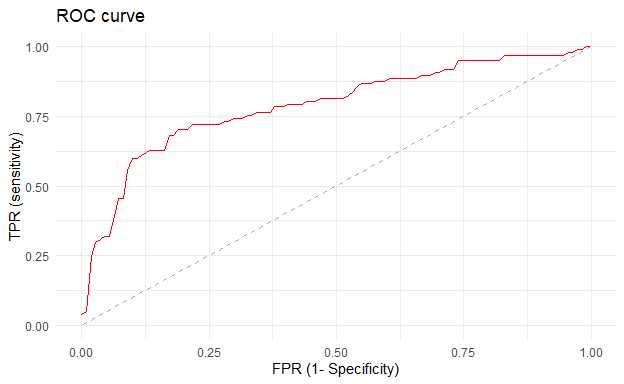

```r
library(pROC)
# Estimating with a logit classifier
pprob <- predict(Logit, twoClass, type = "prob")

# Computing the ROC curve (specificity, Sensitivity) for many threshold
twoclassesROC <- roc(twoClass$classes, pprob$Rural)

# Gathering the results
myROC <- data.frame(cbind(twoclassesROC$specificities,
                          twoclassesROC$sensitivities,
                          twoclassesROC$thresholds)) %>%
  mutate_if(is.numeric, ~ifelse(abs(.) == Inf,NA,.))%>%
  mutate(FPR = 1- X1,
         t = round(X3, 2)) %>%
   rename(Specificity = X1,
         TPR = X2)

# Computing the AUC
twoclassesAUC <-  pROC::auc(twoclassesROC)

# Visualizing
pRoc <- myROC%>%
  distinct(FPR, .keep_all = TRUE) %>%
ggplot() +
 aes(x = FPR, y = TPR, label =  t) +
 geom_line( colour = "red") +
 labs(x = "FPR (1- Specificity)",
      y = "TPR (sensitivity)",
      title = "ROC curve" ) +
 theme_minimal()

# Computing the  isoline

pRoc <- pRoc +  geom_segment(aes(x = 1, xend = 0, y = 1, yend = 0), color="darkgrey", linetype="dashed")

pRoc
```

```r
#For an interactive version, uncomment these lines (needs the plotly package)
library(plotly)
ggplotly(pRoc, tooltip = "label")
```

[interactive chart not shown]

There are various methods to find the best threshold, but one consist of finding the point that is the closest to the top-left part of the plot where specificity and sensitivity would be both = 1.

Alternatively, the optimal threshold can be chosen as the point maximizing the *youden* criteria, defined as $Specificty + Sensitivity -1$, or as point that maximizes the distance to the diagonal line.

Here the best threshold, corresponding to the point closest to top-left of the plot, is:

```r
best.coords <- coords(twoclassesROC, "best",
        best.method="closest.topleft",
       ret=c("threshold", "specificity", "sensitivity"), transpose = FALSE)
best.coords
```

| threshold | specificity | sensitivity |
| --- | --- | --- |
| 0.4878531 | 0.7837838 | 0.7216495 |

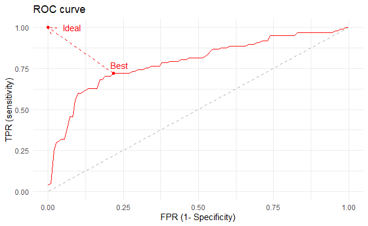

```r
pRoc +
  annotate("point", x = 0,  y = 1,
           size = 1.5, colour = "red") +
  annotate("text", x = 0.08,  y = 1, label = "Ideal",
            colour = "red") +
  annotate("text", x = as.numeric(1-best.coords[2] + 0.02),
            y = as.numeric(best.coords[3]+ 0.05), label = "Best",
           colour = "red") +
  annotate("point", x = as.numeric(1-best.coords[2]),
            y = as.numeric(best.coords[3]),
            size = 1.5, colour = "red") +
  geom_segment(aes(x =  as.numeric(1-best.coords[2]), xend = 0,
                      y = as.numeric(best.coords[3]), yend = 1),
        arrow=arrow(length=unit(0.4,"cm")), linetype=2, color = "red")
```

## The Area Under the Curve (AUC)

The **AUC** (Area Under the Curve) is a measure of fit: Since we would like Specificity and Sensitivity to be 1 for any threshold, the ideal curve has AUC=1.

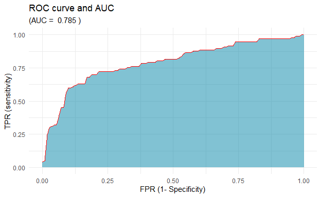

```r
# Computing the AUC
pAUC <- myROC%>%
  distinct(FPR, .keep_all = TRUE) %>%
ggplot() +
 aes(x = FPR, y = TPR) +
  geom_area(aes (x= FPR, y = TPR),
            fill= SIAP.color,
            color = "red",  alpha = 0.5)+
   labs(x = "FPR (1- Specificity)",
      y = "TPR (sensitivity)",
      title = "ROC curve and AUC",
      subtitle =paste("(AUC = ", round(twoclassesAUC, 3), ")") ) +
 theme_minimal()
pAUC
```

# Cross-Validation for Classification

To estimate correctly any of the risk we have chosen, we can rely on cross-validation techniques we have seen for the regression model. Say for instance we want to optimize accuracy.

- Training-Validation: Use the training data to estimate the model and the validation set to estimate the risk by
  $$CV_{validation} = \frac{1}{n_{validation}} \sum_{j \in validation}{ 1
  \left(y_{j} = \widehat{f}(x_{j})\right)}
  \, .$$
- K-fold Cross-Validation: Separate data into K subsamples, repeat Training-validation method $K$ times by using each of the $K$ subsample as validation data, then average the estimated risks.
- These methods can be repeated.
- Leave-One-Out Cross Validation: each of the observations play the role of the validation data in turn, then average the estimated risks.

> For cross validation, we need to choose the number of repetitions for each subsample

```r
# control variables
K <- 5
repeats <- 10
rcvTunes <- 1 # tune number of models

# Choosing a seed allows for reproducibility of results (no need to focus on that)
seed <- 123
# repeated cross validation

rcvSeeds <- setSeeds(method = "repeatedcv",
                     numbers = K,
                     repeats = repeats,
                     tunes = rcvTunes, seed = seed)

ctrl <- trainControl(method = "repeatedcv",
                     number = K,
                     repeats = repeats,
                     seeds = rcvSeeds,
                     classProbs = TRUE,
                     summaryFunction = sixStats)
```

We use here K= 5 and 10 repetition of the process. We then estimate $5 \times10 = 50$ different predictions.

```r
set.seed(1410)
LogitFit <- train(classes ~ ., data = twoClass,
               method = "glm" ,
               preProcess = c("center"),
               trControl = ctrl)
summary(LogitFit)
```

```
##
## Call:
## NULL
##
## Coefficients:
##             Estimate Std. Error z value Pr(>|z|)
## (Intercept)  -0.2382     0.1597  -1.491   0.1359
## Education    -2.3479     1.8524  -1.267   0.2050
## Income       -7.0376     2.1569  -3.263   0.0011 **
## ---
## Signif. codes:  0 '***' 0.001 '**' 0.01 '*' 0.05 '.' 0.1 ' ' 1
##
## (Dispersion parameter for binomial family taken to be 1)
##
##     Null deviance: 287.41  on 207  degrees of freedom
## Residual deviance: 240.01  on 205  degrees of freedom
## AIC: 246.01
##
## Number of Fisher Scoring iterations: 4
```

```r
LogitFit
```

```
## Generalized Linear Model
##
## 208 samples
##   2 predictor
##   2 classes: 'Urban', 'Rural'
##
## Pre-processing: centered (2)
## Resampling: Cross-Validated (5 fold, repeated 10 times)
## Summary of sample sizes: 166, 167, 165, 167, 167, 166, ...
## Resampling results:
##
##   ROC        Sens       Spec       Accuracy   Kappa
##   0.7797087  0.7816206  0.7027895  0.7446628  0.485631
```

> We can visualize the distribution of AUC, sensitivity & specificity for each sample generated in the CV process

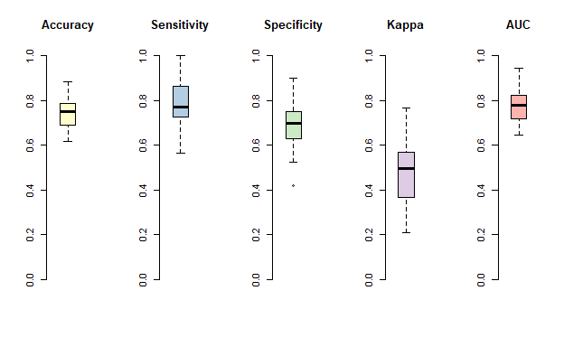

```r
par(mfrow=c(1,5))
boxplot(LogitFit$resample$Accuracy, main="Accuracy",
        col='#ffffcc',ylim = range(0:1),  frame.plot = FALSE)
boxplot(LogitFit$resample$Sens, main="Sensitivity",
        col='#b3cde3',ylim = range(0:1),  frame.plot = FALSE)
boxplot(LogitFit$resample$Spec, main="Specificity",
        col='#ccebc5', ylim = range(0:1), frame.plot = FALSE)
boxplot(LogitFit$resample$Kappa, main="Kappa",
        col='#decbe4',ylim = range(0:1),  frame.plot = FALSE)
boxplot(LogitFit$resample$ROC, main="AUC",
        col='#fbb4ae', ylim = range(0:1), frame.plot = FALSE)
```

# Comparison of Models

All these models use different parameters and have specific advantages and drawbacks. We may still want to compare their **predictive performances** on the various measures of fit. For that we will plot the distribution of the values of these indicators on all the validation samples, for each model.

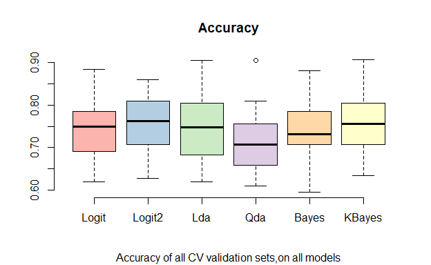

```r
models <- list( Logit = LogitFit, Logit2 = Logit2,
                Lda = Lda, Qda = Qda,  Bayes = Bayes,
                KBayes = KernelBayes)
perf <- resamples(models)

colvec <- c('#fbb4ae','#b3cde3','#ccebc5','#decbe4','#fed9a6','#ffffcc')

# Compiling Accuracy
boxplot(perf$values[c("Logit~Accuracy", "Logit2~Accuracy",
                      "Lda~Accuracy", "Qda~Accuracy",
                      "Bayes~Accuracy", "KBayes~Accuracy")],
        names = names(models), col=colvec,
        main = "Accuracy",
        sub = "Accuracy of all CV validation sets,on all models",
        frame.plot = FALSE)
```

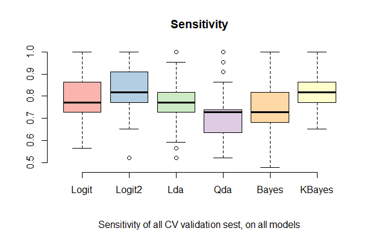

```r
# Compiling Sensitivity
boxplot(perf$values[c("Logit~Sens", "Logit2~Sens",
                      "Lda~Sens", "Qda~Sens",
                      "Bayes~Sens", "KBayes~Sens")],
        names = names(models), col=colvec,
        main = "Sensitivity",
        sub = "Sensitivity of all CV validation sest, on all models",
        frame.plot = FALSE)
```

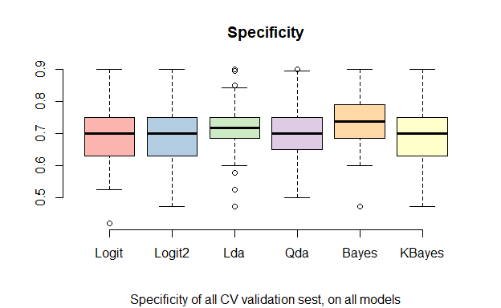

```r
# Compiling Specificity
boxplot(perf$values[c("Logit~Spec", "Logit2~Spec",
                      "Lda~Spec", "Qda~Spec",
                      "Bayes~Spec", "KBayes~Spec")],
        names = names(models), col=colvec,
        main = "Specificity",
        sub = "Specificity of all CV validation sest, on all models",
        frame.plot = FALSE)
```

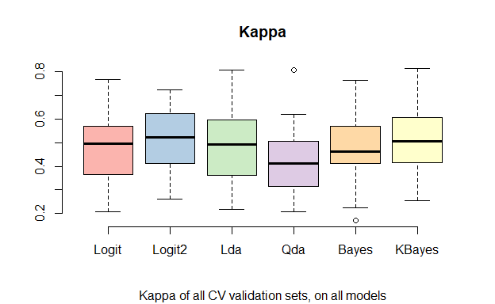

```r
# Compiling Kappa
boxplot(perf$values[c("Logit~Kappa", "Logit2~Kappa",
                      "Lda~Kappa", "Qda~Kappa",
                      "Bayes~Kappa", "KBayes~Kappa")],
        names = names(models), col=colvec,
        main= "Kappa",
        sub = "Kappa of all CV validation sets, on all models",
        frame.plot = FALSE)
```

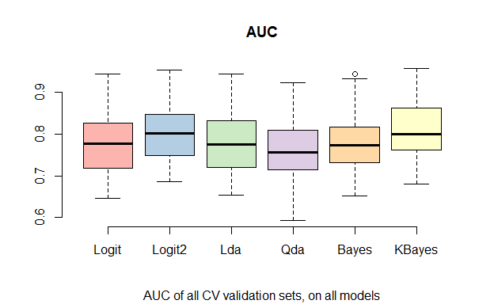

```r
# Compiling AUC
boxplot(perf$values[c("Logit~ROC", "Logit2~ROC",
                      "Lda~ROC", "Qda~ROC",
                      "Bayes~ROC", "KBayes~ROC")],
        names = names(models), col=colvec,
        main= "AUC",
        sub = "AUC of all CV validation sets, on all models",
        frame.plot = FALSE)
```

> Depending on the criterion choosed and on the objective of the prediction, on may prefer one model to another.

# Wrap-up

- In classification, there are a number of adjustment measures that can be computed from the *Confusion matrix*.
- The main ones are *Accuracy*, *Sensitivity* and *Specificty*.
- *Sensitivity* is accuracy restricted to the positives. *Specificity* is accuracy restricted to the negatives.
- When the data set has outcome that imbalanced, one may use kappa $\kappa$ which is a better measure for accuracy.
- Which measure you should consider depends on the context and on your goal.
- *Logit* is a benchmark parametric model for classification, it can be extend to quadratic or more complex forms to adjust for non-linearities.

> Comparing models, adjusting the parameters, inspecting various measures, are time-consuming activities. Still, these choices should be done carefully as they condition the performances on new “*unseen*” data set for prediction.

# Corresponding functions if you use Python

- pandas and numpy offer great functions for handling your data.
- sklearn has a function linear_model.LogisticRegression(), it can also take arguments that allow for regularization as you fit your model.
- the library imbalanced-learn has tools for oversampling, such as the SMOTE algorithm.
- matplotlib offers good visualizations for your results, including feature importance plots.
[^1]: *This document uses teaching materials developped by Pascal Lavergne* (*Toulouse School of Economics*)
[^2]: We assume that an intercept is included in $x$.
[^3]: https://win-vector.com/2009/11/03/i-dont-think-that-means-what-you-think-it-means-statistics-to-english-translation-part-1-accuracy-measures/#wikiSS